**산업체 재직자 대상 인공지능 핵심 기초 교육**  
**Predict Bulk Modulus with PyCaret**

By Prof. Seungchul Lee  
http://iai.postech.ac.kr/  
Industrial AI Lab at POSTECH

Table of Contents

# 1. PyCaret

[figure not shown]

- PyCaret is ideal for:
  - Experienced Data Scientists who want to increase productivity.
  - Citizen Data Scientists who prefer a low code machine learning solution.
  - Data Science Professionals who want to build rapid prototypes.
  - Data Science and Machine Learning students and enthusiasts.
  - https://pycaret.org/ https://pycaret.readthedocs.io/en/latest/index.html
- AutoML
  - Automate from data preprocessing to model validation

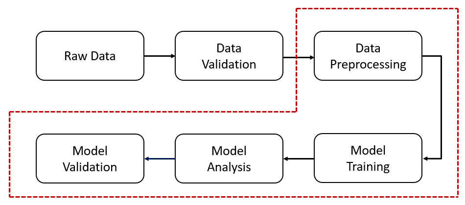

```python
!pip install pycaret
!pip install numpy
```

```python
from google.colab import drive
drive.mount('/content/drive')
```

```python
import pycaret
import pycaret.regression
import pycaret.classification
import numpy as np
import pandas as pd

# filter warnings messages from the notebook
import warnings
warnings.filterwarnings('ignore')
```

# 2. Regression

## 2.1. Feature Extraction

**Descriptors**

- Extract features using matminer
- Colvalent radius, s$\cdot$p$\cdot$d$\cdot$f orbital valence, oxidation state, space group, density, etc.
- Bulk modulus is directly related the interatomic potential and volume per atoms

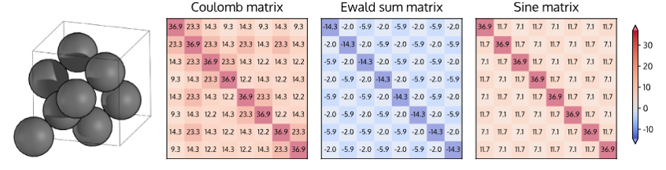

**Dataset**

- Input: Descriptors
- Output: Bulk modulus
- Bulk modulus of a substance is a measure of how resistant to compression the substance is

```python
df_reg = pd.read_csv("/content/drive/MyDrive/linc/data_files/df_reg.csv", index_col = 0)
df_reg
```

|  | k_vrh | vpa | density | MagpieData mean MeltingT | MagpieData mean NUnfilled | packing fraction | MagpieData mode MeltingT | MagpieData minimum NUnfilled | MagpieData maximum GSvolume_pa | MagpieData mean GSvolume_pa | MagpieData minimum NValence | MagpieData mean NdUnfilled | MagpieData mode NUnfilled | MagpieData mean NpValence | MagpieData avg_dev NpUnfilled | MagpieData minimum MeltingT | MagpieData maximum MeltingT | MagpieData maximum NdValence | MagpieData mode GSvolume_pa | MagpieData mean MendeleevNumber | MagpieData minimum Electronegativity | MagpieData minimum MendeleevNumber | std_dev oxidation state |
| --- | --- | --- | --- | --- | --- | --- | --- | --- | --- | --- | --- | --- | --- | --- | --- | --- | --- | --- | --- | --- | --- | --- | --- |
| 0 | 295.077545 | 12.957800 | 13.988541 | 2496.500000 | 4.000000 | 0.570238 | 1687.00 | 4.0 | 20.440000 | 17.265000 | 4.0 | 2.000 | 4.0 | 1.000000 | 2.000000 | 1687.00 | 3306.00 | 6.0 | 14.090000 | 67.500000 | 1.90 | 57.0 | 5.656854 |
| 1 | 74.370488 | 17.868860 | 6.519289 | 1401.760000 | 2.800000 | 0.788912 | 1211.40 | 0.0 | 54.230000 | 24.146000 | 2.0 | 1.200 | 3.0 | 0.800000 | 1.920000 | 1050.00 | 1768.00 | 10.0 | 10.245000 | 56.400000 | 0.95 | 8.0 | 0.000000 |
| 2 | 234.099927 | 15.435634 | 17.027465 | 2016.300000 | 3.500000 | 0.686917 | 2041.40 | 2.0 | 16.690000 | 15.437500 | 4.0 | 2.750 | 2.0 | 0.000000 | 0.000000 | 1941.00 | 2041.40 | 9.0 | 15.020000 | 58.000000 | 1.54 | 43.0 | 2.529822 |
| 3 | 30.178322 | 18.871482 | 3.312854 | 606.150000 | 0.500000 | 0.732266 | 453.69 | 0.0 | 22.890000 | 18.892917 | 1.0 | 0.000 | 1.0 | 0.000000 | 0.000000 | 453.69 | 923.00 | 10.0 | 16.593333 | 35.000000 | 0.98 | 1.0 | 0.000000 |
| 4 | 41.336301 | 19.547245 | 5.439796 | 633.502500 | 0.250000 | 0.705746 | 923.00 | 0.0 | 25.237586 | 21.902730 | 1.0 | 0.000 | 0.0 | 0.000000 | 0.000000 | 234.32 | 923.00 | 10.0 | 22.890000 | 52.000000 | 0.98 | 1.0 | 0.000000 |
| ... | ... | ... | ... | ... | ... | ... | ... | ... | ... | ... | ... | ... | ... | ... | ... | ... | ... | ... | ... | ... | ... | ... | ... |
| 7137 | 62.971555 | 11.111316 | 2.536134 | 470.408750 | 2.250000 | 0.587636 | 54.80 | 1.0 | 16.593333 | 12.401250 | 1.0 | 0.875 | 2.0 | 2.000000 | 1.000000 | 54.80 | 2183.00 | 3.0 | 9.105000 | 49.625000 | 0.98 | 1.0 | 3.043544 |
| 7138 | 278.173744 | 8.570548 | 5.426881 | 2277.285714 | 5.857143 | 0.686866 | 2348.00 | 5.0 | 13.010000 | 9.674286 | 3.0 | 3.000 | 5.0 | 0.571429 | 2.448980 | 2183.00 | 2348.00 | 3.0 | 7.172500 | 60.857143 | 1.63 | 46.0 | 3.346640 |
| 7139 | 32.487326 | 15.415494 | 1.283597 | 743.880588 | 1.705882 | 0.718573 | 453.69 | 1.0 | 20.440000 | 17.498431 | 1.0 | 0.000 | 1.0 | 0.470588 | 1.439446 | 453.69 | 1687.00 | 0.0 | 16.593333 | 19.117647 | 0.98 | 1.0 | 0.000000 |
| 7140 | 44.284962 | 16.322156 | 5.419970 | 388.491429 | 2.000000 | 0.345413 | 54.80 | 0.0 | 31.560000 | 16.214286 | 6.0 | 0.000 | 2.0 | 3.142857 | 0.571429 | 54.80 | 903.78 | 10.0 | 9.105000 | 83.857143 | 1.65 | 69.0 | 3.082207 |
| 7141 | 71.567048 | 11.830199 | 4.046538 | 622.086667 | 1.333333 | 0.675695 | 54.80 | 1.0 | 16.593333 | 12.256111 | 1.0 | 0.000 | 1.0 | 1.333333 | 0.888889 | 54.80 | 1357.77 | 10.0 | 9.105000 | 50.666667 | 0.98 | 1.0 | 1.732051 |

7142 rows × 23 columns

## 2.2. Pipeline Setup

- Initializes the training environment and creates the transformation pipeline
- Setup function must be called before executing any other functions
- It takes two mandatory parameters: "data" and "target"

```python
pipeline = pycaret.regression.setup(data = df_reg,
                                    target = 'k_vrh',
                                    train_size = 0.9,)
```

```python
pipeline1 = pycaret.regression.setup(data = df_reg,
                                     target = 'k_vrh',
                                     train_size = 0.9,
                                     normalize = True)
```

## 2.3. Training

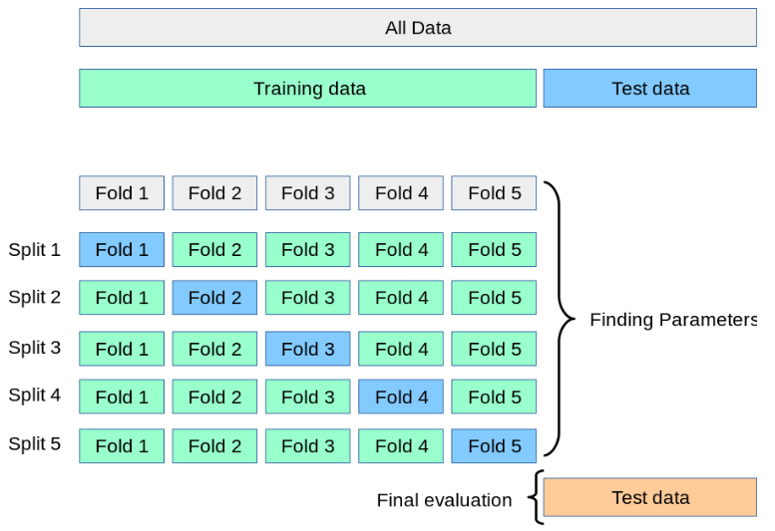

- Top-performing model based on the criteria defined in “sort” parameter
- Show performances based on 10-fold cross validation

```python
top_models = pycaret.regression.compare_models(sort = 'R2')
```

|  | Model | MAE | MSE | RMSE | R2 | RMSLE | MAPE | TT (Sec) |
| --- | --- | --- | --- | --- | --- | --- | --- | --- |
| lightgbm | Light Gradient Boosting Machine | 12.5513 | 459.6107 | 21.1643 | 0.9182 | 0.3309 | 0.3273 | 0.118 |
| et | Extra Trees Regressor | 11.5366 | 464.7293 | 21.2651 | 0.9174 | 0.3137 | 0.3055 | 0.351 |
| rf | Random Forest Regressor | 12.5231 | 507.4415 | 22.2169 | 0.9098 | 0.3239 | 0.3346 | 0.789 |
| gbr | Gradient Boosting Regressor | 15.2204 | 587.4456 | 24.0232 | 0.8955 | 0.3800 | 0.4460 | 0.285 |
| knn | K Neighbors Regressor | 17.9699 | 843.0012 | 28.9140 | 0.8500 | 0.4155 | 0.4304 | 0.024 |
| dt | Decision Tree Regressor | 18.2341 | 1002.9196 | 31.5091 | 0.8220 | 0.4135 | 0.3951 | 0.020 |
| lr | Linear Regression | 27.7876 | 1542.4336 | 39.1697 | 0.7254 | 0.6531 | 1.3724 | 0.242 |
| ridge | Ridge Regression | 27.7866 | 1542.4140 | 39.1694 | 0.7254 | 0.6532 | 1.3725 | 0.007 |
| br | Bayesian Ridge | 27.7824 | 1542.4225 | 39.1688 | 0.7254 | 0.6538 | 1.3729 | 0.006 |
| ada | AdaBoost Regressor | 30.0935 | 1579.4168 | 39.6454 | 0.7187 | 0.6653 | 1.1113 | 0.109 |
| huber | Huber Regressor | 27.3971 | 1584.9443 | 39.6588 | 0.7181 | 0.6652 | 1.6562 | 0.017 |
| lasso | Lasso Regression | 28.4586 | 1607.5087 | 39.9627 | 0.7140 | 0.6513 | 1.4453 | 0.139 |
| en | Elastic Net | 31.1436 | 1829.4415 | 42.6775 | 0.6746 | 0.6600 | 1.1979 | 0.006 |
| lar | Least Angle Regression | 31.0028 | 1951.7904 | 43.3050 | 0.6535 | 0.6958 | 2.0717 | 0.006 |
| par | Passive Aggressive Regressor | 32.3419 | 2082.3204 | 45.5092 | 0.6279 | 0.7276 | 1.7889 | 0.007 |
| omp | Orthogonal Matching Pursuit | 34.1270 | 2236.1223 | 47.1269 | 0.6025 | 0.6844 | 1.8042 | 0.005 |
| llar | Lasso Least Angle Regression | 60.8204 | 5619.1868 | 74.9453 | -0.0013 | 1.0091 | 2.6871 | 0.006 |
| dummy | Dummy Regressor | 60.8204 | 5619.1868 | 74.9453 | -0.0013 | 1.0091 | 2.6871 | 0.005 |

```
INFO:logs:create_model_container: 18
INFO:logs:master_model_container: 18
INFO:logs:display_container: 2
INFO:logs:LGBMRegressor(boosting_type='gbdt', class_weight=None, colsample_bytree=1.0,
              importance_type='split', learning_rate=0.1, max_depth=-1,
              min_child_samples=20, min_child_weight=0.001, min_split_gain=0.0,
              n_estimators=100, n_jobs=-1, num_leaves=31, objective=None,
              random_state=8963, reg_alpha=0.0, reg_lambda=0.0, silent='warn',
              subsample=1.0, subsample_for_bin=200000, subsample_freq=0)
INFO:logs:compare_models() succesfully completed......................................
```

- Check top models

```python
top_models
```

```
LGBMRegressor(boosting_type='gbdt', class_weight=None, colsample_bytree=1.0,
              importance_type='split', learning_rate=0.1, max_depth=-1,
              min_child_samples=20, min_child_weight=0.001, min_split_gain=0.0,
              n_estimators=100, n_jobs=-1, num_leaves=31, objective=None,
              random_state=8963, reg_alpha=0.0, reg_lambda=0.0, silent='warn',
              subsample=1.0, subsample_for_bin=200000, subsample_freq=0)
```

## 2.4. Model Analysis

```python
pycaret.regression.evaluate_model(top_models)
```

```
INFO:logs:Initializing evaluate_model()
INFO:logs:evaluate_model(estimator=LGBMRegressor(boosting_type='gbdt', class_weight=None, colsample_bytree=1.0,
              importance_type='split', learning_rate=0.1, max_depth=-1,
              min_child_samples=20, min_child_weight=0.001, min_split_gain=0.0,
              n_estimators=100, n_jobs=-1, num_leaves=31, objective=None,
              random_state=8963, reg_alpha=0.0, reg_lambda=0.0, silent='warn',
              subsample=1.0, subsample_for_bin=200000, subsample_freq=0), fold=None, fit_kwargs=None, plot_kwargs=None, feature_name=None, groups=None, use_train_data=False)
```

## 2.5. Hyperparameter Tuning

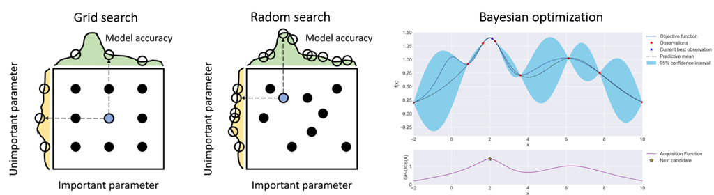

- Grid search, random search, Bayesian optimization, etc.
- It can be seen that the performance improves through hyperparameter tuning
- Pick one model

```python
lasso = pycaret.regression.create_model('lasso')
```

| Fold | MAE | MSE | RMSE | R2 | RMSLE | MAPE |
| --- | --- | --- | --- | --- | --- | --- |
| 0 | 28.5192 | 1521.7115 | 39.0091 | 0.7257 | 0.5832 | 0.6929 |
| 1 | 27.1364 | 1383.5634 | 37.1963 | 0.7513 | 0.6351 | 1.0426 |
| 2 | 30.1295 | 2189.1011 | 46.7878 | 0.6248 | 0.7168 | 2.6050 |
| 3 | 27.9517 | 1400.8153 | 37.4275 | 0.7578 | 0.6405 | 1.0791 |
| 4 | 28.5694 | 1516.2527 | 38.9391 | 0.7264 | 0.6459 | 1.0107 |
| 5 | 27.7307 | 1852.3501 | 43.0389 | 0.6636 | 0.6123 | 0.9723 |
| 6 | 27.4449 | 1415.2228 | 37.6194 | 0.7453 | 0.6884 | 1.4069 |
| 7 | 28.4763 | 1546.6387 | 39.3273 | 0.7370 | 0.6498 | 1.0574 |
| 8 | 27.9573 | 1330.5343 | 36.4765 | 0.7378 | 0.6218 | 0.8339 |
| 9 | 30.6706 | 1918.8976 | 43.8052 | 0.6708 | 0.7188 | 3.7520 |
| Mean | 28.4586 | 1607.5087 | 39.9627 | 0.7140 | 0.6513 | 1.4453 |
| Std | 1.0731 | 268.5361 | 3.2388 | 0.0425 | 0.0420 | 0.9201 |

```
INFO:logs:create_model_container: 24
INFO:logs:master_model_container: 24
INFO:logs:display_container: 6
INFO:logs:Lasso(alpha=1.0, copy_X=True, fit_intercept=True, max_iter=1000,
      normalize=False, positive=False, precompute=False, random_state=8963,
      selection='cyclic', tol=0.0001, warm_start=False)
INFO:logs:create_model() succesfully completed......................................
```

- Tune hyperparameters of the model

```python
tuned_model = pycaret.regression.tune_model(lasso,
                                            optimize = 'R2',
                                            choose_better = True,
                                            n_iter = 100)
```

| Fold | MAE | MSE | RMSE | R2 | RMSLE | MAPE |
| --- | --- | --- | --- | --- | --- | --- |
| 0 | 28.2181 | 1505.1115 | 38.7958 | 0.7287 | 0.5915 | 0.6855 |
| 1 | 26.8962 | 1368.3392 | 36.9911 | 0.7540 | 0.6547 | 1.0298 |
| 2 | 29.6718 | 2131.2471 | 46.1654 | 0.6347 | 0.7007 | 2.4773 |
| 3 | 27.6350 | 1377.8815 | 37.1198 | 0.7618 | 0.6459 | 1.0753 |
| 4 | 28.3718 | 1496.2891 | 38.6819 | 0.7300 | 0.6573 | 1.0024 |
| 5 | 27.5040 | 1838.0846 | 42.8729 | 0.6662 | 0.6207 | 0.9622 |
| 6 | 27.1000 | 1391.0668 | 37.2970 | 0.7496 | 0.6887 | 1.4216 |
| 7 | 28.1216 | 1522.5947 | 39.0204 | 0.7411 | 0.6507 | 1.0832 |
| 8 | 27.9573 | 1328.8340 | 36.4532 | 0.7381 | 0.6262 | 0.8445 |
| 9 | 30.4171 | 1893.0713 | 43.5094 | 0.6752 | 0.7127 | 3.6847 |
| Mean | 28.1893 | 1585.2520 | 39.6907 | 0.7179 | 0.6549 | 1.4267 |
| Std | 1.0435 | 258.5657 | 3.1466 | 0.0411 | 0.0356 | 0.8880 |

```
INFO:logs:create_model_container: 28
INFO:logs:master_model_container: 28
INFO:logs:display_container: 8
INFO:logs:Lasso(alpha=0.65, copy_X=True, fit_intercept=True, max_iter=1000,
      normalize=False, positive=False, precompute=False, random_state=8963,
      selection='cyclic', tol=0.0001, warm_start=False)
INFO:logs:tune_model() succesfully completed......................................
```

**Before hyperparameter tuning**

```python
lasso
```

```
Lasso(alpha=1.0, copy_X=True, fit_intercept=True, max_iter=1000,
      normalize=False, positive=False, precompute=False, random_state=8963,
      selection='cyclic', tol=0.0001, warm_start=False)
```

**After hyperparameter tuning**

```python
tuned_model
```

```
Lasso(alpha=0.65, copy_X=True, fit_intercept=True, max_iter=1000,
      normalize=False, positive=False, precompute=False, random_state=8963,
      selection='cyclic', tol=0.0001, warm_start=False)
```

## 2.6. Prediction

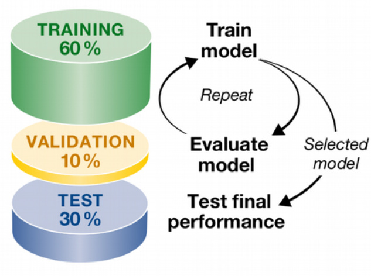

- Generates the label using a trained model
- Test the trained model on unseen data

```python
pycaret.regression.predict_model(tuned_model)
```

```
INFO:logs:Initializing predict_model()
INFO:logs:predict_model(estimator=Lasso(alpha=0.65, copy_X=True, fit_intercept=True, max_iter=1000,
      normalize=False, positive=False, precompute=False, random_state=8963,
      selection='cyclic', tol=0.0001, warm_start=False), probability_threshold=None, encoded_labels=True, drift_report=False, raw_score=False, round=4, verbose=True, ml_usecase=MLUsecase.REGRESSION, display=None, drift_kwargs=None)
INFO:logs:Checking exceptions
INFO:logs:Preloading libraries
INFO:logs:Preparing display monitor
```

|  | Model | MAE | MSE | RMSE | R2 | RMSLE | MAPE |
| --- | --- | --- | --- | --- | --- | --- | --- |
| 0 | Lasso Regression | 29.743099 | 2475.775879 | 49.757198 | 0.6216 | 0.6271 | 0.8459 |

|  | vpa | density | MagpieData mean MeltingT | MagpieData mean NUnfilled | packing fraction | MagpieData mode MeltingT | MagpieData minimum NUnfilled | MagpieData maximum GSvolume_pa | MagpieData mean GSvolume_pa | MagpieData minimum NValence | ... | MagpieData minimum MeltingT | MagpieData maximum MeltingT | MagpieData maximum NdValence | MagpieData mode GSvolume_pa | MagpieData mean MendeleevNumber | MagpieData minimum Electronegativity | MagpieData minimum MendeleevNumber | std_dev oxidation state | k_vrh | Label |
| --- | --- | --- | --- | --- | --- | --- | --- | --- | --- | --- | --- | --- | --- | --- | --- | --- | --- | --- | --- | --- | --- |
| 0 | 0.429238 | -1.174873 | 0.547801 | -0.256900 | -0.228678 | 0.957163 | -1.013308 | 0.382750 | 0.763866 | -0.637166 | ... | 0.781298 | -0.308298 | -1.867937 | 0.443419 | -0.662262 | -1.012297 | -1.122869 | -1.118756 | 59.683075 | 64.425079 |
| 1 | 0.736206 | 0.277781 | -0.000391 | -0.491939 | -0.300702 | -0.135550 | -0.365811 | 0.226905 | 0.525311 | 1.016515 | ... | 0.186390 | -0.160868 | 0.844252 | 1.919290 | 0.776063 | 0.987261 | 0.705372 | 0.442911 | 50.729923 | 89.583176 |
| 2 | 2.047653 | -1.292660 | -1.348242 | -0.632962 | -2.156939 | -0.759968 | -0.365811 | -0.305206 | 0.403248 | 0.740902 | ... | -0.649187 | -1.953912 | 0.844252 | 0.861502 | 1.750412 | 0.939079 | 1.429051 | 0.527385 | 1.313631 | -16.118668 |
| 3 | 1.252849 | -1.390406 | -0.609089 | -0.491939 | -1.458126 | -0.514353 | -0.365811 | -0.238374 | 0.207442 | -0.912780 | ... | -0.320512 | 0.955556 | -0.783062 | 0.994359 | -0.946447 | -1.060479 | -1.351399 | 0.652583 | 10.226559 | 11.035011 |
| 4 | 1.150891 | -0.825682 | -1.042959 | -1.197054 | 0.064222 | -0.759968 | -0.365811 | 3.127445 | 1.903899 | -0.912780 | ... | -0.649187 | -0.845787 | 0.844252 | 0.861502 | 0.442000 | -1.445936 | -1.237134 | -0.134998 | 31.882790 | -1.493050 |
| ... | ... | ... | ... | ... | ... | ... | ... | ... | ... | ... | ... | ... | ... | ... | ... | ... | ... | ... | ... | ... | ... |
| 710 | 0.116621 | 0.734788 | 1.564043 | 1.764431 | 0.374697 | 2.161671 | 1.576683 | 0.150278 | 0.272879 | 0.189675 | ... | -0.143529 | 0.955556 | 0.844252 | 0.210549 | -0.598465 | 0.433167 | 0.400665 | -1.118756 | 165.197098 | 155.993195 |
| 711 | -1.223028 | -1.344673 | 0.641240 | -1.761147 | 0.118338 | 0.813257 | -1.013308 | -1.166025 | -1.348174 | -0.637166 | ... | 1.456055 | -0.459295 | -1.867937 | -0.849729 | 0.219292 | 0.360894 | 1.162433 | -1.118756 | 123.876457 | 135.771759 |
| 712 | -0.223647 | 0.839491 | 0.506405 | -1.479100 | 0.012851 | 1.116990 | -1.013308 | -0.238374 | -0.269003 | 0.465288 | ... | -0.320512 | -0.140596 | 0.844252 | -0.177910 | 0.323687 | 1.878630 | 0.971991 | -1.118756 | 113.941109 | 131.396774 |
| 713 | 0.647935 | -0.629695 | -0.806423 | 0.119161 | 0.067374 | -0.611178 | -1.013308 | 0.382750 | 0.642284 | -0.637166 | ... | -0.450081 | -0.988378 | 0.844252 | 0.280358 | -0.847852 | -1.012297 | -1.122869 | -1.118756 | 42.569702 | 19.685005 |
| 714 | -1.019213 | -0.297963 | 1.283907 | 1.284953 | 0.817437 | 1.515792 | 2.224181 | -0.720778 | -1.031137 | -0.361553 | ... | 0.506043 | 0.477598 | -0.511843 | -0.923660 | -0.059093 | 0.457258 | 0.476842 | -1.118756 | 227.108963 | 184.166656 |

715 rows × 24 columns